# AIML Module Project - Natural Language Processing - Aaditya Kumar Ravi

## **Problem Statement**

### Business Context

In today's dynamic business landscape, organizations are increasingly recognizing the pivotal role customer feedback plays in shaping the trajectory of their products and services. The ability to swiftly and effectively respond to customer input not only fosters enhanced customer experiences but also serves as a catalyst for growth, prolonged customer engagement, and the nurturing of lifetime value relationships. As a dedicated Product Manager or Product Analyst, staying attuned to the voice of your customers is not just a best practice; it's a strategic imperative.

While your organization may be inundated with a wealth of customer-generated feedback and support tickets, your role entails much more than just processing these inputs. To make your efforts in managing customer experience and expectations truly impactful, you need a structured approach – a method that allows you to discern the most pressing issues, set priorities, and allocate resources judiciously. One of the most effective strategies at your disposal is to harness the power of Support Ticket Categorization.

### Objective

Develop an advanced support ticket categorization system that accurately classifies incoming tickets, assigns relevant tags based on their content, implements mechanisms and generate the first response based on the sentiment for prioritizing tickets for prompt resolution.

## **Please read the instructions carefully before starting the project.**

This is a commented Python Notebook file in which all the instructions and tasks to be performed are mentioned.

- Blanks '**___**' are provided in the notebook that needs to be filled with an appropriate code to get the correct result. With every '**___**' blank, there is a comment that briefly describes what needs to be filled in the blank space.
- Identify the task to be performed correctly, and only then proceed to write the required code.
- Please run the codes in a sequential manner from the beginning to avoid any unnecessary errors.
- Add the results/observations (wherever mentioned) derived from the analysis in the presentation and submit the same. Any mathematical or computational details which are a graded part of the project can be included in the Appendix section of the presentation.

## **Installing and Importing Necessary Libraries and Dependencies**

```python
# Installation for GPU llama-cpp-python
# uncomment and run the following code in case GPU is being used

!CMAKE_ARGS="-DLLAMA_CUBLAS=on" FORCE_CMAKE=1 pip install llama-cpp-python==0.1.85 --force-reinstall --no-cache-dir -q
```

[output not shown]

```python
# Installation for CPU llama-cpp-python
# uncomment and run the following code in case GPU is not being used

# !CMAKE_ARGS="-DLLAMA_CUBLAS=off" FORCE_CMAKE=1 pip install llama-cpp-python==0.1.85 --force-reinstall --no-cache-dir -q
```

**Note** : There may be an error related to a dependency issue thrown by the pip package. This can be ignored as it will not impact the execution of the code.

```python
# For downloading the models from HF Hub
!pip install huggingface_hub==0.20.3 pandas==1.5.3 -q
```

[output not shown]

```python
# Function to download the model from the Hugging Face model hub
from huggingface_hub import hf_hub_download

# Importing the Llama class from the llama_cpp module
from llama_cpp import Llama
```

```python
# Importing the json module
import json

# for loading and manipulating data
import pandas as pd

# for time computations
import time
```

## **Loading the Data**

```python
from google.colab import drive
drive.mount('/content/drive')
```

```python
# Complete the code to read the CSV file.
data = pd.read_csv("/content/drive/MyDrive/Colab Notebooks/Support_ticket_text_data_mid_term.csv")
```

## **Data Overview**

### Checking the first 5 rows of the data

```python
# Complete the code to check the first 5 rows of the data
data.head()
```

|  | support_tick_id | support_ticket_text |
| --- | --- | --- |
| 0 | ST2023-006 | My internet connection has significantly slowe... |
| 1 | ST2023-007 | Urgent help required! My laptop refuses to sta... |
| 2 | ST2023-008 | I've accidentally deleted essential work docum... |
| 3 | ST2023-009 | Despite being in close proximity to my Wi-Fi r... |
| 4 | ST2023-010 | My smartphone battery is draining rapidly, eve... |

- Dataframe contains 2 columns support_ticket_id and support_ticket_text

### Checking the shape of the data

```python
# Complete the code to check the shape of the data
data.shape
```

```
(21, 2)
```

- Dataframe has total 21 rows and 2 columns.

### Checking the missing values in the data

```python
# Complete the code to check for missing values in the data
data.isnull().sum()
```

```
support_tick_id        0
support_ticket_text    0
dtype: int64
```

- There are no missing values in this dataset.

## **Model Building**

### Loading the model

```python
model_name_or_path = "TheBloke/Mistral-7B-Instruct-v0.2-GGUF"
model_basename = "mistral-7b-instruct-v0.2.Q6_K.gguf"
```

```python
model_path = hf_hub_download(
    repo_id=model_name_or_path, # Complete the code to mention the repo_id
    filename=model_basename  # Complete the code to mention the filename
)
```

```python
# uncomment and run the following code in case GPU is being used

llm = Llama(
    model_path=model_path,
    n_ctx=1024, # Context window
)
```

```
AVX = 1 | AVX2 = 1 | AVX512 = 0 | AVX512_VBMI = 0 | AVX512_VNNI = 0 | FMA = 1 | NEON = 0 | ARM_FMA = 0 | F16C = 1 | FP16_VA = 0 | WASM_SIMD = 0 | BLAS = 1 | SSE3 = 1 | SSSE3 = 1 | VSX = 0 |
```

```python
# uncomment and run the following code in case GPU is not being used

# llm = Llama(
#     model_path=model_path,
#     n_ctx=1024, # Context window
#     n_cores=-2 # Number of CPU cores to use
# )
```

### Utility functions

```python
# defining a function to parse the JSON output from the model
def extract_json_data(json_str):
    try:
        # Find the indices of the opening and closing curly braces
        json_start = json_str.find('{')
        json_end = json_str.rfind('}')

        if json_start != -1 and json_end != -1:
            extracted_category = json_str[json_start:json_end + 1]  # Extract the JSON object
            data_dict = json.loads(extracted_category)
            return data_dict
        else:
            print(f"Warning: JSON object not found in response: {json_str}")
            return {}
    except json.JSONDecodeError as e:
        print(f"Error parsing JSON: {e}")
        return {}
```

## **Task 1: Ticket Categorization and Returning Structured Output**

```python
# creating a copy of the data
data_1 = data.copy()
```

```python
#Defining the response funciton for Task 1.
def response_1(prompt,ticket):
    model_output = llm(
      f"""
      Q: {prompt}
      Support ticket: {ticket}
      A:
      """,
      max_tokens=32, #Complete the code to set the maximum number of tokens the model should generate for this task.
      stop=["Q:", "\n"],
      temperature=0.01, #Complete the code to set the value for temperature.
      echo=False,
    )

    temp_output = model_output["choices"][0]["text"]
    final_output = temp_output[temp_output.index('{'):]

    return final_output
```

```python
prompt_1 = """
    As a technical assistant, Classify the support ticket according to Support Ticket Text presented in the input
    into the following categories only and not any other categories.
      - Technical issues
      - Hardware issues
      - Data recovery
    Return only a structured JSON output in the following format:
    {"Category": "category_prediction"}
"""
```

**Note**: The output of the model should be in a structured format (JSON format).

```python
start = time.time()
data_1['model_response'] = data_1['support_ticket_text'].apply(lambda x: response_1(prompt_1, x))
end = time.time()
```

[output not shown]

```python
print("Time taken ",(end-start))
```

```
Time taken  293.1676037311554
```

- It has taken 293.16 seconds i.e almost 5 minutes for execution.

```python
# Write the code to check the first five rows of the data to confirm whether the new column has been added
data_1.head()
```

|  | support_tick_id | support_ticket_text | model_response |
| --- | --- | --- | --- |
| 0 | ST2023-006 | My internet connection has significantly slowe... | {"Category": "Technical issues"} |
| 1 | ST2023-007 | Urgent help required! My laptop refuses to sta... | {"Category": "Hardware issues"} |
| 2 | ST2023-008 | I've accidentally deleted essential work docum... | {"Category": "Data recovery"} |
| 3 | ST2023-009 | Despite being in close proximity to my Wi-Fi r... | {"Category": "Technical issues"} |
| 4 | ST2023-010 | My smartphone battery is draining rapidly, eve... | {"Category": "Technical issues"} |

```python
data_1['model_response'].unique()
```

```
array(['{"Category": "Technical issues"}',
       '{"Category": "Hardware issues"}', '{"Category": "Data recovery"}'],
      dtype=object)
```

- We can see model_response column is added and support tickets are categorized as instructed to generate response in structured json format and also categorized tickets in specified categories only.
- Let us view the support ticket and its response at index 2

```python
i = 2
print(data_1.loc[i, 'support_ticket_text'])
```

```
I've accidentally deleted essential work documents, causing substantial data loss. I understand the need to avoid further actions on my device. Can you please prioritize the data recovery process and guide me through it?
```

```python
print(data_1.loc[i, 'model_response'])
```

```
{"Category": "Data recovery"}
```

- Looking at the above support ticket text, it looks like it is a Data Recoery job, and also our model has categorized it correctly.

```python
# applying the function to the model response
data_1['model_response_parsed'] = data_1['model_response'].apply(extract_json_data)
data_1['model_response_parsed'].head()
```

```
0    {'Category': 'Technical issues'}
1     {'Category': 'Hardware issues'}
2       {'Category': 'Data recovery'}
3    {'Category': 'Technical issues'}
4    {'Category': 'Technical issues'}
Name: model_response_parsed, dtype: object
```

```python
data_1['model_response_parsed'].value_counts()
```

```
{'Category': 'Technical issues'}    9
{'Category': 'Data recovery'}       7
{'Category': 'Hardware issues'}     5
Name: model_response_parsed, dtype: int64
```

```python
# Normalizing the model_response_parsed column
model_response_parsed_df_1 = pd.json_normalize(data_1['model_response_parsed'])
model_response_parsed_df_1.head()
```

|  | Category |
| --- | --- |
| 0 | Technical issues |
| 1 | Hardware issues |
| 2 | Data recovery |
| 3 | Technical issues |
| 4 | Technical issues |

```python
# Concatinating two dataframes
data_with_parsed_model_output_1 = pd.concat([data_1, model_response_parsed_df_1], axis=1)
data_with_parsed_model_output_1.head()
```

|  | support_tick_id | support_ticket_text | model_response | model_response_parsed | Category |
| --- | --- | --- | --- | --- | --- |
| 0 | ST2023-006 | My internet connection has significantly slowe... | {"Category": "Technical issues"} | {'Category': 'Technical issues'} | Technical issues |
| 1 | ST2023-007 | Urgent help required! My laptop refuses to sta... | {"Category": "Hardware issues"} | {'Category': 'Hardware issues'} | Hardware issues |
| 2 | ST2023-008 | I've accidentally deleted essential work docum... | {"Category": "Data recovery"} | {'Category': 'Data recovery'} | Data recovery |
| 3 | ST2023-009 | Despite being in close proximity to my Wi-Fi r... | {"Category": "Technical issues"} | {'Category': 'Technical issues'} | Technical issues |
| 4 | ST2023-010 | My smartphone battery is draining rapidly, eve... | {"Category": "Technical issues"} | {'Category': 'Technical issues'} | Technical issues |

```python
# Dropping model_response and model_response_parsed columns
final_data_1 = data_with_parsed_model_output_1.drop(['model_response','model_response_parsed'], axis=1)
final_data_1.head()
```

|  | support_tick_id | support_ticket_text | Category |
| --- | --- | --- | --- |
| 0 | ST2023-006 | My internet connection has significantly slowe... | Technical issues |
| 1 | ST2023-007 | Urgent help required! My laptop refuses to sta... | Hardware issues |
| 2 | ST2023-008 | I've accidentally deleted essential work docum... | Data recovery |
| 3 | ST2023-009 | Despite being in close proximity to my Wi-Fi r... | Technical issues |
| 4 | ST2023-010 | My smartphone battery is draining rapidly, eve... | Technical issues |

- We can see now the categorized tickets added to the dataframe.

## **Task 2: Creating Tags**

```python
# creating a copy of the data
data_2 = data.copy()
```

```python
def response_2(prompt,ticket,category):
    model_output = llm(
      f"""
      Q: {prompt}
      Support ticket: {ticket}
      Category: {category}
      A:
      """,
      max_tokens=64, #Complete the code to set the maximum number of tokens the model should generate for this task.
      stop=["Q:", "\n"],
      temperature=0.01, #Complete the code to set the value for temperature.
      echo=False,
    )

    temp_output = model_output["choices"][0]["text"]
    final_output = temp_output[temp_output.index('{'):]

    return final_output
```

```python
prompt_2 = """
   As per Support Ticket Text and Category provided, identify the following:
   - Tags for the ticket

   Instructions:
     Analyse the Support Ticket Text and identify the important keywords describing the issue in the ticket.

    Return the result in this format {"Tags": "tags_prediction"}
"""
```

**Note**: The output of the model should be in a structured format (JSON format).

```python
start = time.time()
data_2["model_response"]=final_data_1[['support_ticket_text','Category']].apply(lambda x: response_2(prompt_2, x[0],x[1]),axis =1)
end = time.time()
```

[output not shown]

```python
print("Time taken ",end-start)
```

```
Time taken  467.19340777397156
```

- It took 467.19 seconds i.e 7.8 minutes,

```python
# Write the code to check the first five rows of the data to confirm whether the new column has been added
data_2.head()
```

|  | support_tick_id | support_ticket_text | model_response |
| --- | --- | --- | --- |
| 0 | ST2023-006 | My internet connection has significantly slowe... | {"Tags": ["Internet", "Connection", "Slowdown"... |
| 1 | ST2023-007 | Urgent help required! My laptop refuses to sta... | {"Tags": ["Urgent", "Laptop", "Startup", "Hard... |
| 2 | ST2023-008 | I've accidentally deleted essential work docum... | {"Tags": ["Data Loss", "Document Recovery", "D... |
| 3 | ST2023-009 | Despite being in close proximity to my Wi-Fi r... | {"Tags": ["Wi-Fi", "Signal strength", "Trouble... |
| 4 | ST2023-010 | My smartphone battery is draining rapidly, eve... | {"Tags": ["Battery", "Smartphone", "Draining",... |

- We can see the model response column is added with tags created in specified structured json format.
- Let us view the support ticket at index 2

```python
i = 2
print(data_2.loc[i, 'support_ticket_text'])
```

```
I've accidentally deleted essential work documents, causing substantial data loss. I understand the need to avoid further actions on my device. Can you please prioritize the data recovery process and guide me through it?
```

```python
print(data_2.loc[i, 'model_response'])
```

```
{"Tags": ["Data Loss", "Document Recovery", "Data Recovery"]}
```

- We can see the relevent tags created for data recovery related support ticket at index 2.

```python
# Applying the function to the model response
data_2['model_response_parsed'] = data_2['model_response'].apply(extract_json_data)
```

```python
data_2["model_response_parsed"]
```

```
0     {'Tags': ['Internet', 'Connection', 'Slowdown'...
1     {'Tags': ['Urgent', 'Laptop', 'Startup', 'Hard...
2     {'Tags': ['Data Loss', 'Document Recovery', 'D...
3     {'Tags': ['Wi-Fi', 'Signal strength', 'Trouble...
4     {'Tags': ['Battery', 'Smartphone', 'Draining',...
5     {'Tags': ['Account Access', 'Password Reset', ...
6     {'Tags': ['performance', 'computer', 'optimiza...
7     {'Tags': ['Blue Screen', 'Crash', 'Hardware Is...
8     {'Tags': ['External Hard Drive', 'Data Recover...
9     {'Tags': ['Graphics Card', 'Hardware Issue', '...
10    {'Tags': ['Data Recovery', 'USB Drive', 'File ...
11    {'Tags': ['computer', 'screen', 'blackout', 'u...
12    {'Tags': ['accidental_damage', 'water_damage',...
13       {'Tags': ['Physical Damage', 'Data Recovery']}
14         {'Tags': ['touchpad', 'laptop', 'hardware']}
15    {'Tags': ['Internet', 'Connection', 'Drop', 'F...
16    {'Tags': ['Wi-Fi', 'Inconsistent', 'Connectivi...
17    {'Tags': ['data recovery', 'USB drive', 'forma...
18    {'Tags': ['External Hard Drive', 'Data Recover...
19    {'Tags': ['Internet Connection', 'Slow Speed',...
20    {'Tags': ['Software Issues', 'Data Loss', 'Sys...
Name: model_response_parsed, dtype: object
```

```python
# Normalizing the model_response_parsed column
model_response_parsed_df_2 = pd.json_normalize(data_2['model_response_parsed'])
model_response_parsed_df_2.head()
```

|  | Tags |
| --- | --- |
| 0 | [Internet, Connection, Slowdown, Disconnection] |
| 1 | [Urgent, Laptop, Startup, Hardware, Presentation] |
| 2 | [Data Loss, Document Recovery, Data Recovery] |
| 3 | [Wi-Fi, Signal strength, Troubleshooting] |
| 4 | [Battery, Smartphone, Draining, Rapidly] |

```python
# Concatinating two dataframes
data_with_parsed_model_output_2 = pd.concat([data_2, model_response_parsed_df_2], axis=1)
data_with_parsed_model_output_2.head()
```

|  | support_tick_id | support_ticket_text | model_response | model_response_parsed | Tags |
| --- | --- | --- | --- | --- | --- |
| 0 | ST2023-006 | My internet connection has significantly slowe... | {"Tags": ["Internet", "Connection", "Slowdown"... | {'Tags': ['Internet', 'Connection', 'Slowdown'... | [Internet, Connection, Slowdown, Disconnection] |
| 1 | ST2023-007 | Urgent help required! My laptop refuses to sta... | {"Tags": ["Urgent", "Laptop", "Startup", "Hard... | {'Tags': ['Urgent', 'Laptop', 'Startup', 'Hard... | [Urgent, Laptop, Startup, Hardware, Presentation] |
| 2 | ST2023-008 | I've accidentally deleted essential work docum... | {"Tags": ["Data Loss", "Document Recovery", "D... | {'Tags': ['Data Loss', 'Document Recovery', 'D... | [Data Loss, Document Recovery, Data Recovery] |
| 3 | ST2023-009 | Despite being in close proximity to my Wi-Fi r... | {"Tags": ["Wi-Fi", "Signal strength", "Trouble... | {'Tags': ['Wi-Fi', 'Signal strength', 'Trouble... | [Wi-Fi, Signal strength, Troubleshooting] |
| 4 | ST2023-010 | My smartphone battery is draining rapidly, eve... | {"Tags": ["Battery", "Smartphone", "Draining",... | {'Tags': ['Battery', 'Smartphone', 'Draining',... | [Battery, Smartphone, Draining, Rapidly] |

```python
# Dropping model_response and model_response_parsed columns
final_data_2 = data_with_parsed_model_output_2.drop(['model_response','model_response_parsed'], axis=1)
final_data_2.head()
```

|  | support_tick_id | support_ticket_text | Tags |
| --- | --- | --- | --- |
| 0 | ST2023-006 | My internet connection has significantly slowe... | [Internet, Connection, Slowdown, Disconnection] |
| 1 | ST2023-007 | Urgent help required! My laptop refuses to sta... | [Urgent, Laptop, Startup, Hardware, Presentation] |
| 2 | ST2023-008 | I've accidentally deleted essential work docum... | [Data Loss, Document Recovery, Data Recovery] |
| 3 | ST2023-009 | Despite being in close proximity to my Wi-Fi r... | [Wi-Fi, Signal strength, Troubleshooting] |
| 4 | ST2023-010 | My smartphone battery is draining rapidly, eve... | [Battery, Smartphone, Draining, Rapidly] |

- We can see the tags are added as Tags column in a proper comma separated readable format and we have dropped unneccessary columns like model_response and model_response_parsed.

```python
# Checking the value counts of Category column
final_data_2['Tags'].value_counts()
```

```
[External Hard Drive, Data Recovery]                                            2
[Internet, Connection, Slowdown, Disconnection]                                 1
[Data Loss, Document Recovery, Data Recovery]                                   1
[Urgent, Laptop, Startup, Hardware, Presentation]                               1
[Wi-Fi, Signal strength, Troubleshooting]                                       1
[Battery, Smartphone, Draining, Rapidly]                                        1
[performance, computer, optimization, productivity]                             1
[Account Access, Password Reset, Online Banking, Urgent]                        1
[Blue Screen, Crash, Hardware Issue]                                            1
[Graphics Card, Hardware Issue, Gaming Performance]                             1
[Data Recovery, USB Drive, File Recovery]                                       1
[computer, screen, blackout, urgent]                                            1
[accidental_damage, water_damage, laptop, data_recovery]                        1
[Physical Damage, Data Recovery]                                                1
[touchpad, laptop, hardware]                                                    1
[Internet, Connection, Drop, Frequently, Affecting, Work, Urgent]               1
[Wi-Fi, Inconsistent, Connectivity, Router, Work]                               1
[data recovery, USB drive, formatting]                                          1
[Internet Connection, Slow Speed, Disconnections, Productivity Loss, Urgent]    1
[Software Issues, Data Loss, System Errors, Technical Support]                  1
Name: Tags, dtype: int64
```

```python
# Merge Tags and Category data in support ticket dataframe
final_data_2 = pd.concat([final_data_2,final_data_1["Category"]],axis=1)
```

```python
final_data_2 = final_data_2[["support_tick_id","support_ticket_text","Category","Tags"]]
final_data_2
```

|  | support_tick_id | support_ticket_text | Category | Tags |
| --- | --- | --- | --- | --- |
| 0 | ST2023-006 | My internet connection has significantly slowe... | Technical issues | [Internet, Connection, Slowdown, Disconnection] |
| 1 | ST2023-007 | Urgent help required! My laptop refuses to sta... | Hardware issues | [Urgent, Laptop, Startup, Hardware, Presentation] |
| 2 | ST2023-008 | I've accidentally deleted essential work docum... | Data recovery | [Data Loss, Document Recovery, Data Recovery] |
| 3 | ST2023-009 | Despite being in close proximity to my Wi-Fi r... | Technical issues | [Wi-Fi, Signal strength, Troubleshooting] |
| 4 | ST2023-010 | My smartphone battery is draining rapidly, eve... | Technical issues | [Battery, Smartphone, Draining, Rapidly] |
| 5 | ST2023-011 | I'm locked out of my online banking account an... | Technical issues | [Account Access, Password Reset, Online Bankin... |
| 6 | ST2023-012 | My computer's performance is sluggish, severel... | Technical issues | [performance, computer, optimization, producti... |
| 7 | ST2023-013 | I'm experiencing a recurring blue screen error... | Hardware issues | [Blue Screen, Crash, Hardware Issue] |
| 8 | ST2023-014 | My external hard drive isn't being recognized ... | Data recovery | [External Hard Drive, Data Recovery] |
| 9 | ST2023-015 | The graphics card in my gaming laptop seems to... | Hardware issues | [Graphics Card, Hardware Issue, Gaming Perform... |
| 10 | ST2023-016 | I accidentally formatted my USB drive with cri... | Data recovery | [Data Recovery, USB Drive, File Recovery] |
| 11 | ST2023-017 | My computer's screen has gone black, and I can... | Hardware issues | [computer, screen, blackout, urgent] |
| 12 | ST2023-018 | I accidentally spilled water on my laptop, and... | Data recovery | [accidental_damage, water_damage, laptop, data... |
| 13 | ST2023-019 | My USB flash drive is physically damaged, and ... | Data recovery | [Physical Damage, Data Recovery] |
| 14 | ST2023-020 | The touchpad on my laptop has stopped working,... | Hardware issues | [touchpad, laptop, hardware] |
| 15 | ST2023-021 | My internet connection is frequently dropping,... | Technical issues | [Internet, Connection, Drop, Frequently, Affec... |
| 16 | ST2023-022 | Wi-Fi is inconsistent despite proximity to the... | Technical issues | [Wi-Fi, Inconsistent, Connectivity, Router, Work] |
| 17 | ST2023-023 | I accidentally formatted my USB drive with cru... | Data recovery | [data recovery, USB drive, formatting] |
| 18 | ST2023-024 | My external hard drive isn't being recognized,... | Data recovery | [External Hard Drive, Data Recovery] |
| 19 | ST2023-025 | I am experiencing a critical problem with my i... | Technical issues | [Internet Connection, Slow Speed, Disconnectio... |
| 20 | ST2023-026 | I hope this message finds you well. I am writi... | Technical issues | [Software Issues, Data Loss, System Errors, Te... |

```python
final_data_2.shape
```

```
(21, 4)
```

```python
# Let us save the data final_data_2 in drive for future use, so that we don't need to run above process again to get these details. and we can directly load it.
final_data_2.to_csv("/content/drive/MyDrive/final_data_2.csv", index=False)
```

## **Task 3: Assigning Priority and ETA**

```python
# creating a copy of the data
data_3 = data.copy()
```

```python
def response_3(prompt,ticket,category,tags):
    model_output = llm(
      f"""
      Q: {prompt}
      Support ticket: {ticket}
      Category: {category}
      Tags: {tags}
      A:
      """,
      max_tokens=64,  #Complete the code to set the maximum number of tokens the model should generate for this task.
      stop=["Q:", "\n"],
      temperature=0.01, #Complete the code to set the value for temperature.
      echo=False,
    )

    temp_output = model_output["choices"][0]["text"]
    final_output = temp_output[temp_output.index('{'):]

    return final_output
```

```python
prompt_3 = """
    Based on the Support Ticket Text, Category, and Tags provided, identify the following:
    - Priority for resolving the ticket (Low, Medium, High)
    - ETA for resolving the ticket (Within 24 hours, Within 2-4 hours, Within 48 hours, ASAP)

    Instructions:
    1. Carefully read the support ticket text and consider the overall sentiment while assigning the priority.
    2. The priority must be one of Low, Medium, or High only
    3. Not all tickets can be of high priority.
    4. Based on the sentiment, priority, and nature of the issue, suggest an appropriate ETA for resolution.
    5. The ETA must be one of Within 24 hours, Within 2-4 hours, Within 48 hours, or ASAP only.

     Return the result in the following JSON format:
     {"Priority": "priority_prediction", "ETA": "eta_prediction"}
"""
```

**Note**: The output of the model should be in a structured format (JSON format).

```python
# Applying generate_llama_response function on support_ticket_text column
start = time.time()
data_3['model_response'] = final_data_2[['support_ticket_text','Category','Tags']].apply(lambda x: response_3(prompt_3, x[0],x[1],x[2]),axis=1)
end = time.time()
```

[output not shown]

```python
print("Time taken ",(end-start))
```

```
Time taken  332.8444314002991
```

- It took 332 seconds i.e 5.5 minutes to execute.

```python
# Write the code to check the first five rows of the data to confirm whether the new column has been added
data_3.head()
```

|  | support_tick_id | support_ticket_text | model_response |
| --- | --- | --- | --- |
| 0 | ST2023-006 | My internet connection has significantly slowe... | {"Priority": "High", "ETA": "ASAP"} |
| 1 | ST2023-007 | Urgent help required! My laptop refuses to sta... | {"Priority": "High", "ETA": "ASAP"} |
| 2 | ST2023-008 | I've accidentally deleted essential work docum... | {"Priority": "High", "ETA": "ASAP"} |
| 3 | ST2023-009 | Despite being in close proximity to my Wi-Fi r... | {"Priority": "Medium", "ETA": "Within 24 hours"} |
| 4 | ST2023-010 | My smartphone battery is draining rapidly, eve... | {"Priority": "Medium", "ETA": "Within 24 hours"} |

```python
i = 2
print(data_3.loc[i, 'support_ticket_text'])
```

```
I've accidentally deleted essential work documents, causing substantial data loss. I understand the need to avoid further actions on my device. Can you please prioritize the data recovery process and guide me through it?
```

```python
print(data_3.loc[i, 'model_response'])
```

```
{"Priority": "High", "ETA": "ASAP"}
```

- Support ticket at index 2 has been assigned High Priority and ASAP ETA.

```python
# Applying the function to the model response
data_3['model_response_parsed'] = data_3['model_response'].apply(extract_json_data)
data_3['model_response_parsed'].head()
```

```
0                 {'Priority': 'High', 'ETA': 'ASAP'}
1                 {'Priority': 'High', 'ETA': 'ASAP'}
2                 {'Priority': 'High', 'ETA': 'ASAP'}
3    {'Priority': 'Medium', 'ETA': 'Within 24 hours'}
4    {'Priority': 'Medium', 'ETA': 'Within 24 hours'}
Name: model_response_parsed, dtype: object
```

```python
# Normalizing the model_response_parsed column
model_response_parsed_df_3 = pd.json_normalize(data_3['model_response_parsed'])
model_response_parsed_df_3.head(21)
```

|  | Priority | ETA |
| --- | --- | --- |
| 0 | High | ASAP |
| 1 | High | ASAP |
| 2 | High | ASAP |
| 3 | Medium | Within 24 hours |
| 4 | Medium | Within 24 hours |
| 5 | High | ASAP |
| 6 | High | Within 24 hours |
| 7 | High | Within 24 hours |
| 8 | High | ASAP |
| 9 | High | Within 24 hours |
| 10 | High | ASAP |
| 11 | High | ASAP |
| 12 | High | ASAP |
| 13 | High | ASAP |
| 14 | Medium | Within 48 hours |
| 15 | High | ASAP |
| 16 | High | Within 4 hours |
| 17 | High | ASAP |
| 18 | High | ASAP |
| 19 | High | ASAP |
| 20 | High | Within 48 hours |

```python
# Concatinating two dataframes
data_with_parsed_model_output_3 = pd.concat([data_3, model_response_parsed_df_3], axis=1)
data_with_parsed_model_output_3.head()
```

|  | support_tick_id | support_ticket_text | model_response | model_response_parsed | Priority | ETA |
| --- | --- | --- | --- | --- | --- | --- |
| 0 | ST2023-006 | My internet connection has significantly slowe... | {"Priority": "High", "ETA": "ASAP"} | {'Priority': 'High', 'ETA': 'ASAP'} | High | ASAP |
| 1 | ST2023-007 | Urgent help required! My laptop refuses to sta... | {"Priority": "High", "ETA": "ASAP"} | {'Priority': 'High', 'ETA': 'ASAP'} | High | ASAP |
| 2 | ST2023-008 | I've accidentally deleted essential work docum... | {"Priority": "High", "ETA": "ASAP"} | {'Priority': 'High', 'ETA': 'ASAP'} | High | ASAP |
| 3 | ST2023-009 | Despite being in close proximity to my Wi-Fi r... | {"Priority": "Medium", "ETA": "Within 24 hours"} | {'Priority': 'Medium', 'ETA': 'Within 24 hours'} | Medium | Within 24 hours |
| 4 | ST2023-010 | My smartphone battery is draining rapidly, eve... | {"Priority": "Medium", "ETA": "Within 24 hours"} | {'Priority': 'Medium', 'ETA': 'Within 24 hours'} | Medium | Within 24 hours |

```python
# Dropping model_response and model_response_parsed columns
final_data_3 = data_with_parsed_model_output_3.drop(['model_response','model_response_parsed'], axis=1)
final_data_3.head()
```

|  | support_tick_id | support_ticket_text | Priority | ETA |
| --- | --- | --- | --- | --- |
| 0 | ST2023-006 | My internet connection has significantly slowe... | High | ASAP |
| 1 | ST2023-007 | Urgent help required! My laptop refuses to sta... | High | ASAP |
| 2 | ST2023-008 | I've accidentally deleted essential work docum... | High | ASAP |
| 3 | ST2023-009 | Despite being in close proximity to my Wi-Fi r... | Medium | Within 24 hours |
| 4 | ST2023-010 | My smartphone battery is draining rapidly, eve... | Medium | Within 24 hours |

```python
final_data_3 = pd.concat([final_data_3,final_data_2[["Category","Tags"]]],axis=1)
```

```python
final_data_3 = final_data_3[["support_tick_id","support_ticket_text","Category","Tags","Priority","ETA"]]
```

```python
final_data_3
```

|  | support_tick_id | support_ticket_text | Category | Tags | Priority | ETA |
| --- | --- | --- | --- | --- | --- | --- |
| 0 | ST2023-006 | My internet connection has significantly slowe... | Technical issues | [Internet, Connection, Slowdown, Disconnection] | High | ASAP |
| 1 | ST2023-007 | Urgent help required! My laptop refuses to sta... | Hardware issues | [Urgent, Laptop, Startup, Hardware, Presentation] | High | ASAP |
| 2 | ST2023-008 | I've accidentally deleted essential work docum... | Data recovery | [Data Loss, Document Recovery, Data Recovery] | High | ASAP |
| 3 | ST2023-009 | Despite being in close proximity to my Wi-Fi r... | Technical issues | [Wi-Fi, Signal strength, Troubleshooting] | Medium | Within 24 hours |
| 4 | ST2023-010 | My smartphone battery is draining rapidly, eve... | Technical issues | [Battery, Smartphone, Draining, Rapidly] | Medium | Within 24 hours |
| 5 | ST2023-011 | I'm locked out of my online banking account an... | Technical issues | [Account Access, Password Reset, Online Bankin... | High | ASAP |
| 6 | ST2023-012 | My computer's performance is sluggish, severel... | Technical issues | [performance, computer, optimization, producti... | High | Within 24 hours |
| 7 | ST2023-013 | I'm experiencing a recurring blue screen error... | Hardware issues | [Blue Screen, Crash, Hardware Issue] | High | Within 24 hours |
| 8 | ST2023-014 | My external hard drive isn't being recognized ... | Data recovery | [External Hard Drive, Data Recovery] | High | ASAP |
| 9 | ST2023-015 | The graphics card in my gaming laptop seems to... | Hardware issues | [Graphics Card, Hardware Issue, Gaming Perform... | High | Within 24 hours |
| 10 | ST2023-016 | I accidentally formatted my USB drive with cri... | Data recovery | [Data Recovery, USB Drive, File Recovery] | High | ASAP |
| 11 | ST2023-017 | My computer's screen has gone black, and I can... | Hardware issues | [computer, screen, blackout, urgent] | High | ASAP |
| 12 | ST2023-018 | I accidentally spilled water on my laptop, and... | Data recovery | [accidental_damage, water_damage, laptop, data... | High | ASAP |
| 13 | ST2023-019 | My USB flash drive is physically damaged, and ... | Data recovery | [Physical Damage, Data Recovery] | High | ASAP |
| 14 | ST2023-020 | The touchpad on my laptop has stopped working,... | Hardware issues | [touchpad, laptop, hardware] | Medium | Within 48 hours |
| 15 | ST2023-021 | My internet connection is frequently dropping,... | Technical issues | [Internet, Connection, Drop, Frequently, Affec... | High | ASAP |
| 16 | ST2023-022 | Wi-Fi is inconsistent despite proximity to the... | Technical issues | [Wi-Fi, Inconsistent, Connectivity, Router, Work] | High | Within 4 hours |
| 17 | ST2023-023 | I accidentally formatted my USB drive with cru... | Data recovery | [data recovery, USB drive, formatting] | High | ASAP |
| 18 | ST2023-024 | My external hard drive isn't being recognized,... | Data recovery | [External Hard Drive, Data Recovery] | High | ASAP |
| 19 | ST2023-025 | I am experiencing a critical problem with my i... | Technical issues | [Internet Connection, Slow Speed, Disconnectio... | High | ASAP |
| 20 | ST2023-026 | I hope this message finds you well. I am writi... | Technical issues | [Software Issues, Data Loss, System Errors, Te... | High | Within 48 hours |

- We can see important columns has been concatenated to the dataframe and dropped unnecessary columns.

```python
# Let us save the data final_data_3 in drive for future use, so that we don't need to run above process again to get this dataframe. we can directly load it.
final_data_3.to_csv("/content/drive/MyDrive/final_data_3.csv", index=False)
```

```python
#Let us view if it is saved.
load_final_data_3 = pd.read_csv("/content/drive/MyDrive/final_data_3.csv")
load_final_data_3.head()
```

[output not shown]

## **Task 4 - Creating a Draft Response**

```python
# creating a copy of the data
data_4 = data.copy()
```

```python
def response_4(prompt,ticket,category,tags,priority,eta):
    model_output = llm(
      f"""
      Q: {prompt}
      Support ticket: {ticket}
      Category : {category}
      Tags : {tags}
      Priority: {priority}
      ETA: {eta}
      A:
      """,
      max_tokens=80, #Complete the code to set the maximum number of tokens the model should generate for this task.
      stop=["Q:", "\n"],
      temperature=0.4, #Complete the code to set the value for temperature.
      echo=False,
    )

    temp_output = model_output["choices"][0]["text"]


    return temp_output
```

```python
prompt_4 = """
    Based on provided details like Support Ticket Text, Category of the ticket, Tags, Priority for resolving the issue and ETA for resolution,
    draft a response that can be shared with the customer.

    Instructions:
    1. Carefully read Support Ticket Text and consider the overall sentiment of the review.
    2. Use the tags and category for summarizing.
    3. Mention the ETA in the response.
    4. Ensure the response is empathetic.
    5. Keep the response under 50 words.

    Return only the response to be shared with the customer, with no additional information.
"""
```

**Note** : For this task, we will not be using the *`extract_json_data`* function. Hence, the output from the model should be a plain string and not a JSON object.

```python
#Applying generate_llama_response function on support_ticket_text column
start = time.time()
data_4['model_response'] = final_data_3[['support_ticket_text','Category','Tags','Priority','ETA']].apply(lambda x: response_4(prompt_4, x[0],x[1],x[2],x[3],x[4]),axis=1)
end = time.time()
```

[output not shown]

```python
print("Time taken",(end-start))
```

```
Time taken 803.6558263301849
```

- It took 803 seconds i.e 13.3 minutes to execute.

```python
# Write the code to check the first five rows of the data to confirm whether the new column has been added
data_4.head()
```

|  | support_tick_id | support_ticket_text | model_response |
| --- | --- | --- | --- |
| 0 | ST2023-006 | My internet connection has significantly slowe... | We apologize for the inconvenience you're exp... |
| 1 | ST2023-007 | Urgent help required! My laptop refuses to sta... | We're deeply sorry for the inconvenience caus... |
| 2 | ST2023-008 | I've accidentally deleted essential work docum... | We deeply apologize for your data loss. Our t... |
| 3 | ST2023-009 | Despite being in close proximity to my Wi-Fi r... | We apologize for your ongoing Wi-Fi connectiv... |
| 4 | ST2023-010 | My smartphone battery is draining rapidly, eve... | We're sorry for the inconvenience you've expe... |

- Let us view the support ticket and its generated rsponse at index 2

```python
i = 2
print(data_4.loc[i, 'support_ticket_text'])
```

```
I've accidentally deleted essential work documents, causing substantial data loss. I understand the need to avoid further actions on my device. Can you please prioritize the data recovery process and guide me through it?
```

```python
print(data_4.loc[i, 'model_response'])
```

```
 We deeply apologize for your data loss. Our team will prioritize the data recovery process (ASAP). Please avoid using your device to prevent further data loss. We'll guide you through the recovery steps shortly.
```

- Support ticket and index was High priority and ASAP ETA ticket, so We can see it has generated appropriate reply response.

```python
final_data_4 = pd.concat([final_data_3,data_4["model_response"]],axis=1)
```

```python
final_data_4.rename(columns={"model_response":"Response"},inplace=True)
```

```python
final_data_4
```

|  | support_tick_id | support_ticket_text | Category | Tags | Priority | ETA | Response |
| --- | --- | --- | --- | --- | --- | --- | --- |
| 0 | ST2023-006 | My internet connection has significantly slowe... | Technical issues | [Internet, Connection, Slowdown, Disconnection] | High | ASAP | We apologize for the inconvenience you're exp... |
| 1 | ST2023-007 | Urgent help required! My laptop refuses to sta... | Hardware issues | [Urgent, Laptop, Startup, Hardware, Presentation] | High | ASAP | We're deeply sorry for the inconvenience caus... |
| 2 | ST2023-008 | I've accidentally deleted essential work docum... | Data recovery | [Data Loss, Document Recovery, Data Recovery] | High | ASAP | We deeply apologize for your data loss. Our t... |
| 3 | ST2023-009 | Despite being in close proximity to my Wi-Fi r... | Technical issues | [Wi-Fi, Signal strength, Troubleshooting] | Medium | Within 24 hours | We apologize for your ongoing Wi-Fi connectiv... |
| 4 | ST2023-010 | My smartphone battery is draining rapidly, eve... | Technical issues | [Battery, Smartphone, Draining, Rapidly] | Medium | Within 24 hours | We're sorry for the inconvenience you've expe... |
| 5 | ST2023-011 | I'm locked out of my online banking account an... | Technical issues | [Account Access, Password Reset, Online Bankin... | High | ASAP | Dear Customer, |
| 6 | ST2023-012 | My computer's performance is sluggish, severel... | Technical issues | [performance, computer, optimization, producti... | High | Within 24 hours | We're sorry for the inconvenience you've expe... |
| 7 | ST2023-013 | I'm experiencing a recurring blue screen error... | Hardware issues | [Blue Screen, Crash, Hardware Issue] | High | Within 24 hours | We're sorry for the inconvenience caused by y... |
| 8 | ST2023-014 | My external hard drive isn't being recognized ... | Data recovery | [External Hard Drive, Data Recovery] | High | ASAP | We understand the urgency of your situation a... |
| 9 | ST2023-015 | The graphics card in my gaming laptop seems to... | Hardware issues | [Graphics Card, Hardware Issue, Gaming Perform... | High | Within 24 hours | Dear Valued Customer, |
| 10 | ST2023-016 | I accidentally formatted my USB drive with cri... | Data recovery | [Data Recovery, USB Drive, File Recovery] | High | ASAP | We're deeply sorry for your data loss. Our te... |
| 11 | ST2023-017 | My computer's screen has gone black, and I can... | Hardware issues | [computer, screen, blackout, urgent] | High | ASAP | We're deeply sorry for the inconvenience you'... |
| 12 | ST2023-018 | I accidentally spilled water on my laptop, and... | Data recovery | [accidental_damage, water_damage, laptop, data... | High | ASAP | We're deeply sorry for your laptop mishap. Ou... |
| 13 | ST2023-019 | My USB flash drive is physically damaged, and ... | Data recovery | [Physical Damage, Data Recovery] | High | ASAP | We're deeply sorry for the inconvenience caus... |
| 14 | ST2023-020 | The touchpad on my laptop has stopped working,... | Hardware issues | [touchpad, laptop, hardware] | Medium | Within 48 hours | We're sorry for the inconvenience with your l... |
| 15 | ST2023-021 | My internet connection is frequently dropping,... | Technical issues | [Internet, Connection, Drop, Frequently, Affec... | High | ASAP | We're sorry to hear about the disruption to y... |
| 16 | ST2023-022 | Wi-Fi is inconsistent despite proximity to the... | Technical issues | [Wi-Fi, Inconsistent, Connectivity, Router, Work] | High | Within 4 hours | We apologize for the inconvenience you're exp... |
| 17 | ST2023-023 | I accidentally formatted my USB drive with cru... | Data recovery | [data recovery, USB drive, formatting] | High | ASAP | We're deeply sorry for the inconvenience caus... |
| 18 | ST2023-024 | My external hard drive isn't being recognized,... | Data recovery | [External Hard Drive, Data Recovery] | High | ASAP | We understand the urgency of your situation r... |
| 19 | ST2023-025 | I am experiencing a critical problem with my i... | Technical issues | [Internet Connection, Slow Speed, Disconnectio... | High | ASAP | Dear Valued Customer, |
| 20 | ST2023-026 | I hope this message finds you well. I am writi... | Technical issues | [Software Issues, Data Loss, System Errors, Te... | High | Within 48 hours | Dear Valued Customer, |

```python
# Let us save the data final_data_4 in drive for future use, so that we don't need to run above process again to get these details.
final_data_4.to_csv("/content/drive/MyDrive/final_data_4.csv", index=False)
```

```python
#Let us view if it is saved.
final_data_4 = pd.read_csv("/content/drive/MyDrive/final_data_4.csv")
final_data_4.head()
```

|  | support_tick_id | support_ticket_text | Category | Tags | Priority | ETA | Response |
| --- | --- | --- | --- | --- | --- | --- | --- |
| 0 | ST2023-006 | My internet connection has significantly slowe... | Technical issues | ['Internet', 'Connection', 'Slowdown', 'Discon... | High | ASAP | We apologize for the inconvenience you're exp... |
| 1 | ST2023-007 | Urgent help required! My laptop refuses to sta... | Hardware issues | ['Urgent', 'Laptop', 'Startup', 'Hardware', 'P... | High | ASAP | We're deeply sorry for the inconvenience caus... |
| 2 | ST2023-008 | I've accidentally deleted essential work docum... | Data recovery | ['Data Loss', 'Document Recovery', 'Data Recov... | High | ASAP | We deeply apologize for your data loss. Our t... |
| 3 | ST2023-009 | Despite being in close proximity to my Wi-Fi r... | Technical issues | ['Wi-Fi', 'Signal strength', 'Troubleshooting'] | Medium | Within 24 hours | We apologize for your ongoing Wi-Fi connectiv... |
| 4 | ST2023-010 | My smartphone battery is draining rapidly, eve... | Technical issues | ['Battery', 'Smartphone', 'Draining', 'Rapidly'] | Medium | Within 24 hours | We're sorry for the inconvenience you've expe... |

## **Model Output Analysis**

```python
# Creating a copy of the dataframe of task-4
final_data = final_data_4.copy()
```

```python
final_data['Category'].value_counts()    # complete the code with the column name for the column containing ticket categories
```

```
Technical issues    9
Data recovery       7
Hardware issues     5
Name: Category, dtype: int64
```

- We have total 9 technical issues, 7 data recovery related issues and 5 hardware issues.
- We have higher count of technical issues, followed by data recovery and then hardware issues.

```python
final_data["Priority"].value_counts() # complete the code with the column name for the column containing the priorities of the ticket.
```

```
High      18
Medium     3
Name: Priority, dtype: int64
```

- It has assigned High priority to 18 support tickets and medium priority to 3 support tickets.
- None of the tickets is assigned low priority.

```python
final_data["ETA"].value_counts()# complete the code with the column name for the column containing ticket resolution ETA.
```

```
ASAP               13
Within 24 hours     5
Within 48 hours     2
Within 4 hours      1
Name: ETA, dtype: int64
```

- It has assigned 13 support tickets to ASAP ETA, Within 24 hours resolution to 5 tickets, Within 48 hours resolution to 2 tickets and Within 4 hours resolution time to 1 ticket.

Let's dive in a bit deeper here.

```python
final_data.groupby(['Category', 'ETA']).support_tick_id.count() # complete the code to group by based on the categories and ETA.
```

```
Category          ETA
Data recovery     ASAP               7
Hardware issues   ASAP               2
                  Within 24 hours    2
                  Within 48 hours    1
Technical issues  ASAP               4
                  Within 24 hours    3
                  Within 4 hours     1
                  Within 48 hours    1
Name: support_tick_id, dtype: int64
```

```python
final_data.groupby(['Category', 'Priority', 'ETA']).support_tick_id.count()
```

```
Category          Priority  ETA
Data recovery     High      ASAP               7
Hardware issues   High      ASAP               2
                            Within 24 hours    2
                  Medium    Within 48 hours    1
Technical issues  High      ASAP               4
                            Within 24 hours    1
                            Within 4 hours     1
                            Within 48 hours    1
                  Medium    Within 24 hours    2
Name: support_tick_id, dtype: int64
```

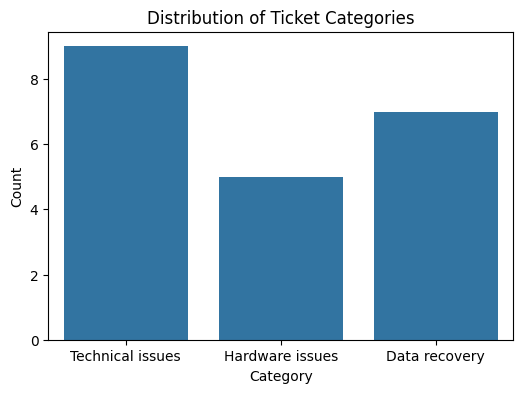

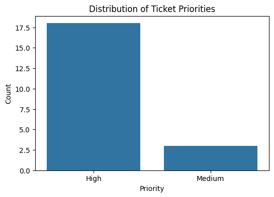

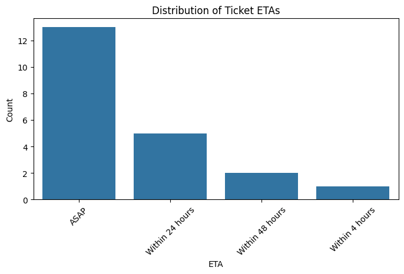

```python
# See visualizations
import matplotlib.pyplot as plt
import seaborn as sns

# Univariate analysis for 'Category'
plt.figure(figsize=(6, 4))
sns.countplot(x='Category', data=final_data)
plt.title('Distribution of Ticket Categories')
plt.xlabel('Category')
plt.ylabel('Count')
plt.show()

# Univariate analysis for 'Priority'
plt.figure(figsize=(6, 4))
sns.countplot(x='Priority', data=final_data)
plt.title('Distribution of Ticket Priorities')
plt.xlabel('Priority')
plt.ylabel('Count')
plt.show()

# Univariate analysis for 'ETA'
plt.figure(figsize=(8, 4))
sns.countplot(x='ETA', data=final_data)
plt.title('Distribution of Ticket ETAs')
plt.xlabel('ETA')
plt.ylabel('Count')
plt.xticks(rotation=45)
plt.show()
```

**Insights:**

- 13 out of 21 support tickets have an ASAP ETA, indicating many urgent issues.
- All 7 support tickets of Data Recovery are ASAP ETA, highlighting criticality.
- 5 support tickets in Hardware issues with varied ETAs like Within 24 hours and 48 hours, suggesting different urgency levels.
- 9 support tickets distributed across all ETAs i.e ASAP, Within 24 hrs, 48 hrs and 4 hrs.
- Focus is more on Data Recovery and Technical Issues due to high ASAP tickets.

## **Actionable Insights and Recommendations**

**Observations and Insights:**

- High Volume of Urgent Issues: 13 out of 21 tickets require immediate attention (ASAP).
- All Data Recovery tickets are marked as ASAP, indicating high priority and potential business impact.
- Technical Issues show a wide range of ETAs, suggesting varying levels of complexity and urgency.

**Recommendations:**

- Increase support staff for Data Recovery and Technical Issues to handle the high volume of urgent tickets.
- Develop a system to prioritize tickets effectively and ensure that the most critical issues are addressed first.
- Streamline processes for resolving Issues to reduce resolution time and improve overall efficiency.
- Implement preventative strategies and provide additional training to reduce the occurrence of high-priority Technical Issues.
- Regularly monitor ticket categories and ETAs to identify trends and areas needing improvement, ensuring a proactive approach to support management.

Power Ahead